# Chapter 7: Example Walkthrough

Tyler Richards

## Example 7.1: Construction and Operation of a Fraction Nonconforming Control Chart

Frozen orange juice concentrate is packed in 6-oz cardboard cans. These cans are formed on a machine by spinning them from cardboard stock and attaching a metal bottom panel. By inspection of a can, we may determine whether, when filled, it could possibly leak either on the side seam or around the bottom joint. Such a nonconforming can has an improper seal on either the side seam or the bottom panel. Set up a control chart to improve the fraction of nonconforming cans produced by this machine.

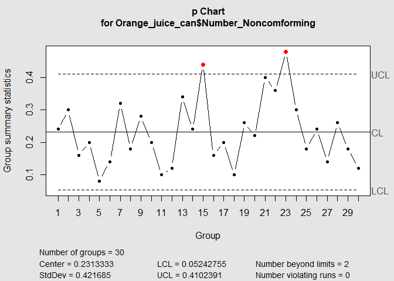

```r
library(qcc)
Orange_juice_can <- read.csv("Orange_Juice_cans.csv") #read the data into R
names(Orange_juice_can) <- c("Number_Noncomforming", "Percent_Nonconforming") #use the names() function to give column names
Orange_juice_can$size <- 50 #sample size is not variable here, set the size to 50
OJ_pchart <- qcc(Orange_juice_can$Number_Noncomforming, sizes = Orange_juice_can$size, type = "p") #call the qcc function with type set to p. The $ symbol gives the column from a dataframe
```

```r
#we don't actually use the percent nonconforming column because R calculates this for us
```

Analysis of the data from sample 15 indicates that a new batch of cardboard stock was put into production during that half-hour period. The introduction of new batches of raw material sometimes causes irregular production performance, and it is reasonable to believe that this has occurred here. Furthermore, during the half-hour period in which sample 23 was obtained, a relatively inexperienced operator had been temporarily assigned to the machine, and this could account for the high fraction nonconforming obtained from that sample. Consequently, samples 15 and 23 are eliminated and the chart redrawn.

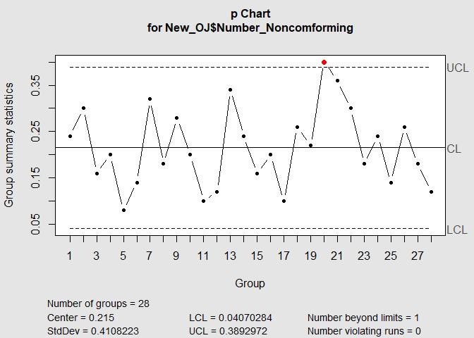

```r
#eliminate row 15 and 23 of the data
New_OJ <- Orange_juice_can[-c(15,23),] #we remove rows by making a vector with the c() function, and putting a negative sign before it which can be read as "everything except row 15 and 23".
New_OJ_pchart <- qcc(New_OJ$Number_Noncomforming, sizes = New_OJ$size, type = "p")
```

## Example 7.2: An np Control chart

Set up an np control chart for the orange juice concentrate can process in Example 7.1.

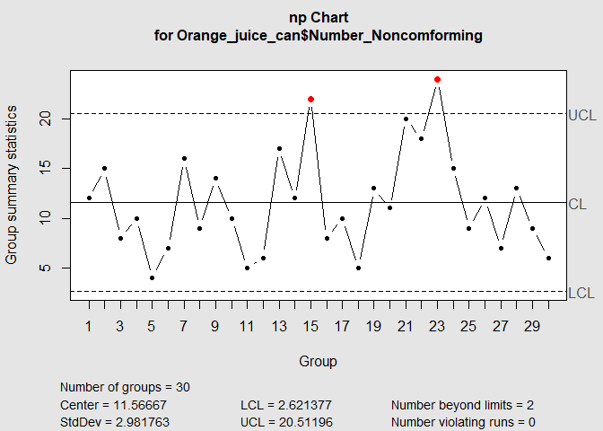

```r
#use the data from 7.1, switch type to np
OJ_npchart <- qcc(Orange_juice_can$Number_Noncomforming, sizes = Orange_juice_can$size, type = "np")
```

## Example 7.2.2 Variable Sample Size

Use data in table 7.4 to construct a control chart to improve the fraction of nonconforming units for purchase order data.

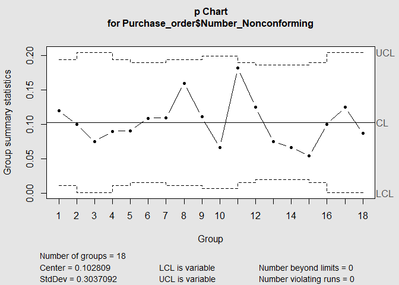

```r
Purchase_order <- read.csv("Purchase_order.csv", header = T)
names(Purchase_order) <- c("Sample_Size", "Number_Nonconforming")
#there is no difference in R with variable sample size
Purchase_order_chart <- qcc(Purchase_order$Number_Nonconforming, sizes = Purchase_order$Sample_Size, type = "p")
```

## Example 7.2.3 Standardized Control Chart

Use the data from table 7.4 to create a standardized control chart about the purchase order data.

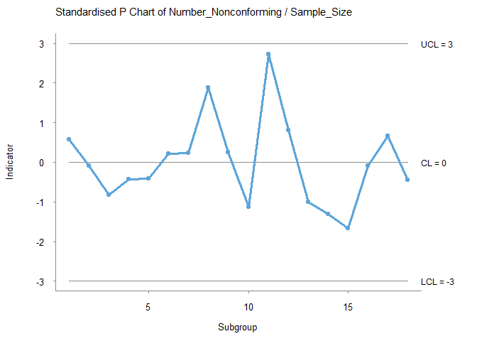

```r
#qicharts has a better function for standardized control charts than the qcc package, so we'll use that
#run install.packages("qicharts") if you do not have the package yet
library(qicharts)
qic(data = Purchase_order,
    n = Sample_Size,
    y = Number_Nonconforming,
    chart = 'p',
    standardised = T
    )
```

## Example 7.3: Nonconformities in Printed Circuit Boards

Table 7.7 presents the number of nonconformities observed in 26 successive samples of 100 printed circuit boards. Note that, for reasons of convenience, the inspection unit is defined as 100 boards. Set up a c chart for these data.

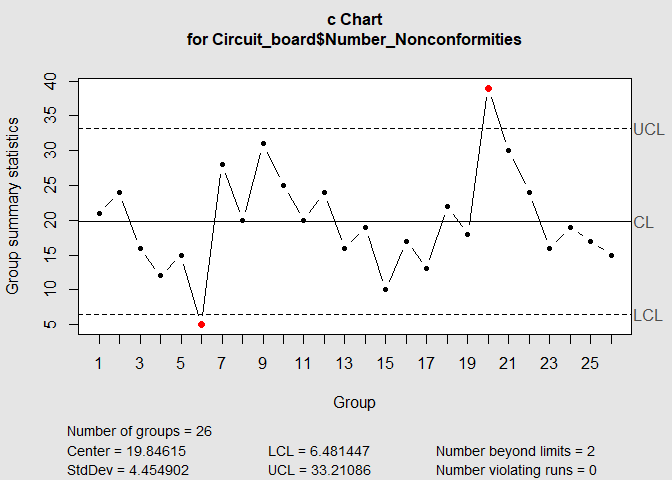

```r
#read these data into R
Circuit_board <- read.csv("Printed_Circuit_Board.csv")
names(Circuit_board) <- c("Sample_Size", "Number_Nonconformities")

#use the qcc function to make the c chart
Circuit_board_chart <- qcc(Circuit_board$Number_Nonconformities, sizes = Circuit_board$Sample_Size, type = "c")
```

## Example 7.4: Control Charts in Supply Chain Operations

A supply chain engineering group monitors shipments of materials through the company distribution network. Errors on either the delivered material or the accompanying documentation are tracked on a weekly basis. Fifty randomly selected shipments are examined and the errors recorded. Data for twenty weeks are shown in Table 7.10. Set up a u control chart to monitor this process.

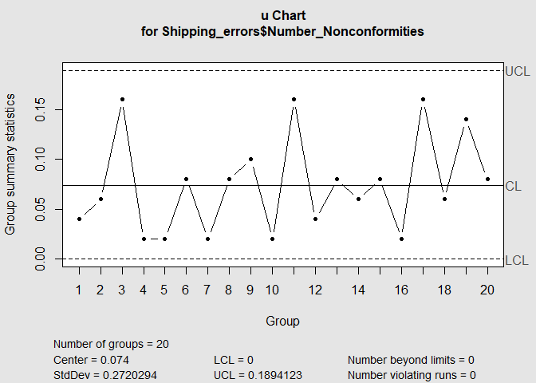

```r
#read in these data
Shipping_errors <- read.csv("Shipping_errors.csv")
names(Shipping_errors) <- c("Sample_Size", "Number_Nonconformities")

#use the qcc function to get a u chart
Shipping_errors_chart <- qcc(Shipping_errors$Number_Nonconformities, sizes = Shipping_errors$Sample_Size, type = "u")
```

## Example 7.5: Dyed Cloth Defects per unit - u chart

In a textile finishing plant, dyed cloth is inspected for the occurrence of defects per 50 square meters. The data on ten rolls of cloth are shown in Table 7.11. Use these data to set up a control chart for nonconformities per unit.

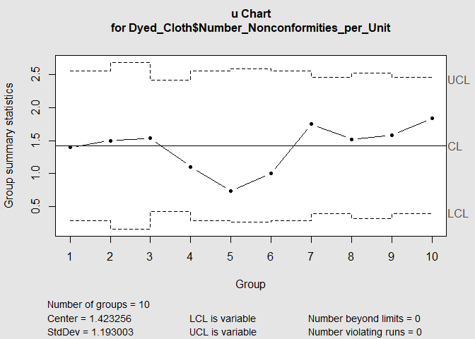

```r
#read these data into R from table 7.11
#for this problem we need only the third and fourth column. R will calculate the rest.
Dyed_Cloth <- read.csv("Dyed_Cloth.csv")
names(Dyed_Cloth) <- c("Sample_Size", "Number_Nonconformities_per_Unit")

#use the qcc function to graph the control chart
Dyed_Cloth_chart <- qcc(Dyed_Cloth$Number_Nonconformities_per_Unit, sizes = Dyed_Cloth$Sample_Size, type = "u")
```